# Kaggle Titanic Competition - Data Exploration & Model Building

Rahul Sangole

Aug 31, 2017

# Objectives

1. End to end analysis using R
2. Learn the caret package for ML
3. Learn to present the case using R Notebooks

# Read in the dataset

I stored the raw files on Github, so I used [RCurl](https://cran.r-project.org/web/packages/RCurl/index.html) with [Wehrley’s method](https://github.com/wehrley/wehrley.github.io/blob/master/SOUPTONUTS.md) that utilizes read.csv to the fullest. It’s one of the best ways I’ve found to read in data and also set data-types at the same time. He’s done a great job on that function. The dataset contains one ID variable, one response variable and ten predictor variables.

```r
library(RCurl,quietly = T)
library(tidyverse,quietly = T)
library(ggplot2,quietly = T)
library(gridExtra,quietly = T)
library(Amelia,quietly = T)
library(beanplot,quietly = T)
library(caret,quietly = T)
library(stringr,quietly = T)
library(party, quietly = T)
# library(rattle, quietly = T)
readData <- function(path.name, file.name, column.types, missing.types) {
    gurl <- paste(path.name,file.name,sep="")
    download.file(gurl,file.name,method="curl",quiet = T)
    tbl_df(read.csv(file.name,colClasses=column.types,
             na.strings=missing.types))
}
Titanic.path <- "https://raw.githubusercontent.com/rsangole/Titanic/master/"
train.data.file <- "train.csv"
test.data.file <- "test.csv"
missing.types <- c("NA", "")
train.column.types <- c('integer',   # PassengerId
                        'factor',    # Survived
                        'factor',    # Pclass
                        'character', # Name
                        'factor',    # Sex
                        'numeric',   # Age
                        'integer',   # SibSp
                        'integer',   # Parch
                        'character', # Ticket
                        'numeric',   # Fare
                        'character', # Cabin
                        'factor'     # Embarked
)
test.column.types <- train.column.types[-2]     # # no Survived column in test.csv
train.raw <- readData(Titanic.path, train.data.file,train.column.types,missing.types)
test.raw <- readData(Titanic.path, test.data.file,test.column.types,missing.types)
prep_data <- function(D) {
    if (!is.null(D$Survived)) {
        D$Survived <- factor(D$Survived,
                             levels = c(1, 0),
                             labels = c('Survived', 'Dead'))
        }
    D$Pclass <- factor(D$Pclass,
                       levels = c(1, 2, 3),
                       labels = c('P1', 'P2', 'P3'))
    D$PassengerId <- NULL
    D
}
train.raw <- prep_data(train.raw)
test.raw <- prep_data(test.raw)
str(train.raw)
```

```
Classes ‘tbl_df’, ‘tbl’ and 'data.frame':   891 obs. of  11 variables:
 $ Survived: Factor w/ 2 levels "Survived","Dead": 2 1 1 1 2 2 2 2 1 1 ...
 $ Pclass  : Factor w/ 3 levels "P1","P2","P3": 3 1 3 1 3 3 1 3 3 2 ...
 $ Name    : chr  "Braund, Mr. Owen Harris" "Cumings, Mrs. John Bradley (Florence Briggs Thayer)" "Heikkinen, Miss. Laina" "Futrelle, Mrs. Jacques Heath (Lily May Peel)" ...
 $ Sex     : Factor w/ 2 levels "female","male": 2 1 1 1 2 2 2 2 1 1 ...
 $ Age     : num  22 38 26 35 35 NA 54 2 27 14 ...
 $ SibSp   : int  1 1 0 1 0 0 0 3 0 1 ...
 $ Parch   : int  0 0 0 0 0 0 0 1 2 0 ...
 $ Ticket  : chr  "A/5 21171" "PC 17599" "STON/O2. 3101282" "113803" ...
 $ Fare    : num  7.25 71.28 7.92 53.1 8.05 ...
 $ Cabin   : chr  NA "C85" NA "C123" ...
 $ Embarked: Factor w/ 3 levels "C","Q","S": 3 1 3 3 3 2 3 3 3 1 ...
```

# Missing values analysis

Quick investigation of missing values can be done using the `complete.cases()`, and more thorough graphical summary can be done using Amelia. Overall, 79% of the observations have *some* missing data.

```r
#Complete cases (percentages)
round(prop.table(table(complete.cases(train.raw))),2)
```

```
FALSE  TRUE
 0.79  0.21
```

Amelia lets us graphically investigate which variables have missing data. `purr::map_xxx()` gives this same information numerically in a succint fashion.

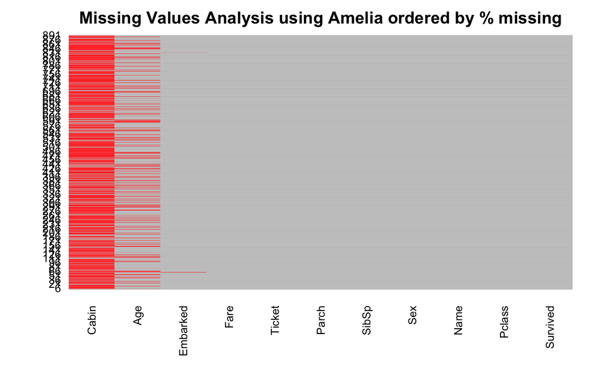

```r
missmap(train.raw, main='Missing Values Analysis using Amelia ordered by % missing', col=c('red', 'gray'),legend = F,rank.order = T)
```

```r
#Missing cases (numbers):
map_int(train.raw,~sum(is.na(.x)))
```

```
Survived   Pclass     Name      Sex      Age    SibSp    Parch   Ticket     Fare    Cabin
       0        0        0        0      177        0        0        0        0      687
Embarked
       2
```

```r
#Missing cases (percentages):
round(map_dbl(train.raw,~sum(is.na(.x))/length(.x)),2)
```

```
Survived   Pclass     Name      Sex      Age    SibSp    Parch   Ticket     Fare    Cabin
    0.00     0.00     0.00     0.00     0.20     0.00     0.00     0.00     0.00     0.77
Embarked
    0.00
```

Cabin has a large number of missing values (77% missing). Imputing this variable may prove challenging or even useless. Age (19.9% missing) and Embarked (0.2%) missing are much more managable.

# EDA

The first step in the analysis is to explore the data numerically and graphically. I always split up my EDA investigation as follows:

- Target Variable
- Predictor Variables
  - Univariate
  - Bivariate
  - Multivariate

This gives me a structured approach towards larger datasets. My [professor](http://www.syamalasrinivasan.com/) at Northwestern taught me to always complete a thorough intimate numeric & graphical EDA on the data, no matter how large the data [^1]. [Anscombe](http://www.jstor.org/stable/2682899) (1973) clearly shows the importance of graphical analyses.

## Target Variable

`Survived` is the response variable. As we can see, a large majority of the passengers did not survive the accident. The response variable is a False/True boolean variable. Thus, the analysis techniques used later will be those appropriate for classification problems.

```r
round(prop.table(table(train.raw$Survived)),2)
```

```
Survived     Dead
    0.38     0.62
```

## Predictor Variables

### Univariate & Bivariate

The first step is to look at every variable available. I prefer using the `ggplot2` framework for all the visuals.

#### Continuous Variables

- `Age` seems to have a bimodal distribution - very young children, and then directly young adults to mid-age persons. The 2nd mode is right skewed with no obvious outliers.
- `Fare` certainly shows many outliers beyond the ~$200 level. A majority of the fares are <$50, which makes sense since a majority of the travelers are bound to be in the 3rd passenger class.

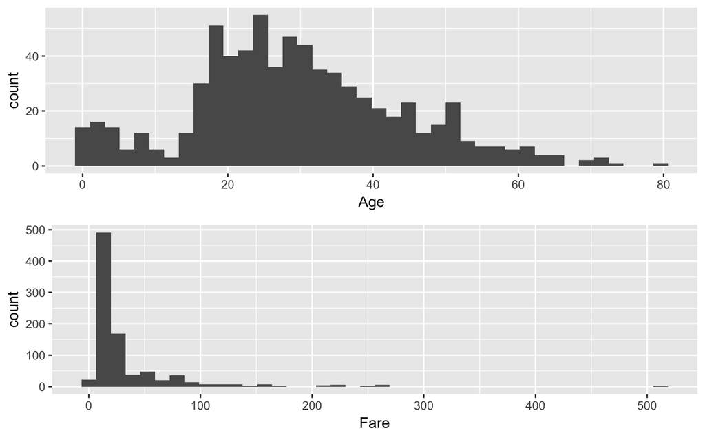

```r
p1 <- ggplot(data=train.raw,aes(x=Age))+geom_histogram(bins = 40)
p2 <- ggplot(data=train.raw,aes(x=Fare))+geom_histogram(bins = 40)
grid.arrange(p1,p2)
```

As we can see, the median fare is $14.5, the mean is $32, but the max is $512. We’ll investigate winzorising this variable in the latter part. Perhaps a transformation will also help?

```r
summary(train.raw$Fare)
```

```
   Min. 1st Qu.  Median    Mean 3rd Qu.    Max.
   0.00    7.91   14.45   32.20   31.00  512.33
```

#### Categorical Variables

A ggplot command is iterated over for the categorical variables.[^2]

Key takeways for the categorical variables:

1. `Pclass`: If you were traveling 1st class, you have the highest chance of survival. Could be indicative of preferential treatment to those who paid more, a less politically correct class-stratified society, as well as the fact that the 1st class passengers had cabins at the very top of the ship.
2. `Pclass`: Persons traveling 3rd class had the highest fatality rate. 3rd class passengers had cabins deep in the ship. With the reasons give in (1), this could have contributed to the low survival rate.
3. `Sex`: Males have a very high fatality rate. Seems like the ‘women and children’ first policy was followed during evacuation.
4. `SibSp` & `Parch`: What’s interesting here is, for both these variables, at level 0, the fatality rate is higher. At levels 1+, the chances of survival are much better. Again, this could point to the ‘women *and children*’ policy being followed. (Or perhaps there weren’t as many families with children on board!)
5. `Embarked`: Southampton has a higher fatality rate than Cherbourg or Queenstown. A cross-tabulation between `Embarked` and `Pclass` shows that 72% of the 3rd class passengers and 89% of the 2nd class passengers boarded at Southampton. This jives with the observation that 2nd and 3rd class passengers have higher fatality rates.

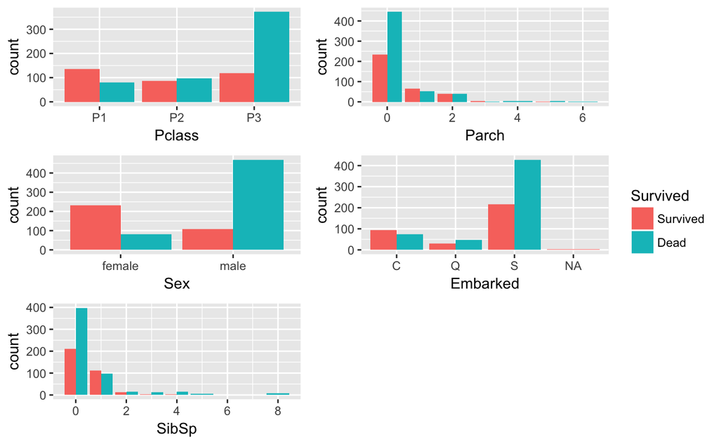

```r
get_legend<-function(myggplot){
  tmp <- ggplot_gtable(ggplot_build(myggplot))
  leg <- which(sapply(tmp$grobs, function(x) x$name) == "guide-box")
  legend <- tmp$grobs[[leg]]
  return(legend)
}
p <- lapply(X = c('Pclass','Sex','SibSp','Parch','Embarked'),
            FUN = function(x) ggplot(data = train.raw)+
                aes_string(x=x,fill='Survived')+
                geom_bar(position="dodge")+
                theme(legend.position="none"))
legend <- get_legend(ggplot(data = train.raw,aes(x=Pclass,fill=Survived))+geom_bar())
grid.arrange(p[[1]],p[[2]],p[[3]],p[[4]],p[[5]],legend,layout_matrix =
                 cbind(c(1,2,3),c(4,5,NA),c(6,6,6)),widths=c(3,3,1))
```

```r
# round(prop.table(table(train.raw$Embarked,train.raw$Pclass),margin = 2),2)
```

### Multivariate Analyses

Grouped boxplots are a common method of comparing distributions grouped by categorical variables. I find [beanplots](https://cran.r-project.org/web/packages/beanplot/beanplot.pdf) to be excellent complementary plots to boxplots (and in some cases, even better). They’re a bit tricky to read at first - since they are so underutilized - but just through one plot, a wealth of information can be extracted.[^3]

Here is a comparison of the same information between a boxplot and a beanplot. What can we infer from the bean plot better?

1. The beanplot allows us to visualize the density function of the parameter, in this case: Age. Furthermore, the length of each beanline is cumulative to the number of datapoints that exist. Rightaway, we can tell that Pclass=3 has the most data in the set, with sparser data at Pclass=1.
2. The mean values for 1st class is higher than that for 2nd and 3rd class. The distributions of deceased and survived for 1st class are fairly similar.
3. For 2nd and 3rd class, the survived data shows a bimodal distribution. Bumps at the 0-10 age show that children were evacuated first. This is also the reason the mean values for survived is lower.
4. For 2nd and 3rd class, the deceased data shows a fairly normal distribution.
5. The individual measurements (represented by black lines) represent each observation and help identify outliers much more easily than a boxplot does.

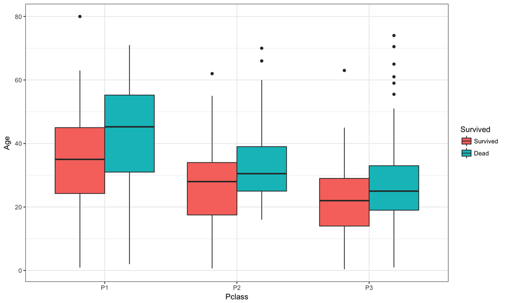

```r
ggplot(train.raw,aes(y=Age,x=Pclass))+geom_boxplot(aes(fill=Survived))+theme_bw()
```

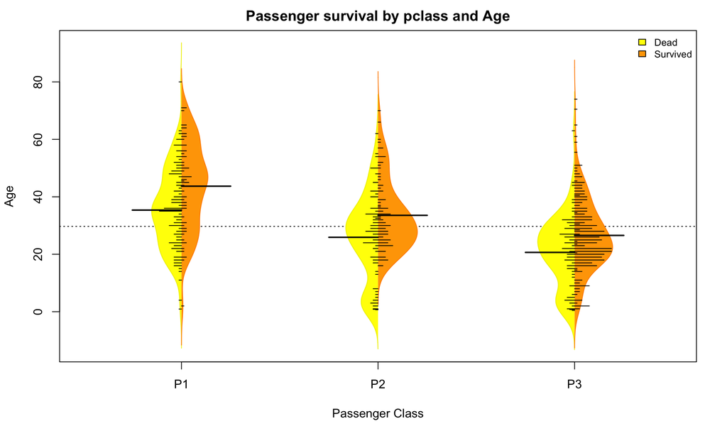

```r
beanplot(Age~Survived*Pclass,side='b',train.raw,col=list('yellow','orange'),
         border = c('yellow2','darkorange'),ll = 0.05,boxwex = .5,
         main='Passenger survival by pclass and Age',xlab='Passenger Class',ylab='Age')
legend('topright', fill = c('yellow','orange'), legend = c("Dead", "Survived"),bty = 'n',cex = .8)
```

A look into the `SibSp` and `Parch` variables shows something interesting. There are three regions one can identify:

- The probability of survival is minimal for number of parents/children aboard > 3.
- The probability of survival is minimal for number of siblings/spouses aboard > 3.
- For `SibSp`<=3 and `Parch`<=3, there are better chances for survival.

These could be simple rules either hard coded during model building: something along the lines of: *IF (SibSp>3 OR Parch >3) THEN prediction = 0*, or some derived variables can be created.

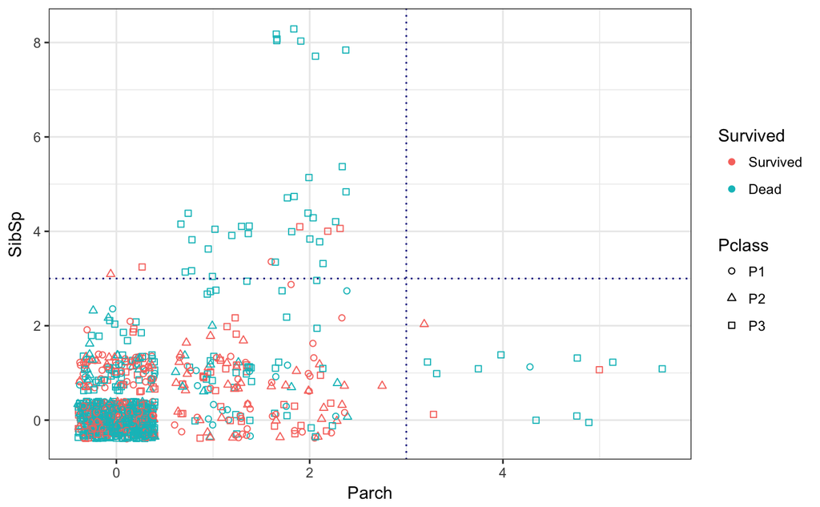

```r
ggplot(train.raw,aes(y=SibSp,x=Parch))+
    geom_jitter(aes(color=Survived,shape=Pclass))+
    theme_bw()+
    scale_shape(solid=F)+
    geom_vline(xintercept = 3,color='darkblue',lty=3)+
    geom_hline(yintercept = 3,color='darkblue',lty=3)
```

# Data Preparation

## Missing Values Imputation

Starting with the easier one first:

**Embarked**: The largest portion of the passengers embared at Southhampton. I’m replacing the NAs with the same. First, I create a new imputed training dataset.

```r
summary(train.raw$Embarked)
```

```
   C    Q    S NA's
 168   77  644    2
```

```r
train.imp <- train.raw
train.imp$Embarked[is.na(train.imp$Embarked)]='S'
```

**Names, Titles & Age**:

The names have titles embedded in the strings. I can extract these using regex. Master, Miss, Mr and Mrs are the most popular - no surprise there, with lots of other titles. Here’s the distribution of the titles by age. These can be used to impute the missing age values.

```r
train.raw$title <- str_extract(pattern = '[a-zA-Z]+(?=\\.)',string = train.raw$Name)
train.raw$title <- as.factor(train.raw$title)
train.raw %>%
    na.omit() %>%
    group_by(title) %>%
    dplyr::summarise(Count=n(), Median_Age=round(median(Age),0)) %>%
    arrange(-Median_Age)
```

| title | Count | Median_Age |
| --- | --- | --- |
| Capt | 1 | 70 |
| Col | 1 | 56 |
| Sir | 1 | 49 |
| Lady | 1 | 48 |
| Major | 2 | 48 |
| Dr | 3 | 44 |
| Mr | 81 | 38 |
| Mrs | 38 | 38 |
| Countess | 1 | 33 |
| Miss | 44 | 26 |

[output cut: 3 more lines]

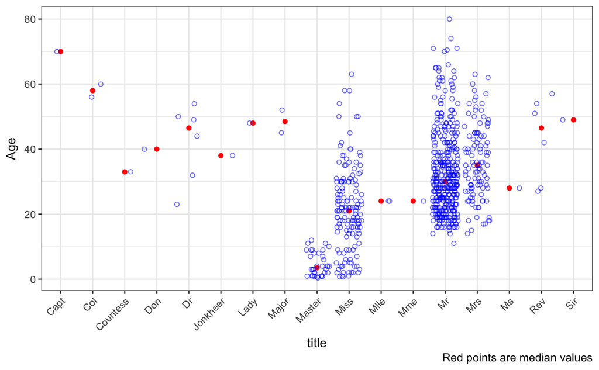

```r
ggplot(train.raw,aes(x=title,y=Age))+
    stat_summary(aes(y = Age,group=1), fun.y=median, colour="red", geom="point",group=1)+
    geom_jitter(shape=21,alpha=.6,col='blue')+
    theme_bw()+
    theme(axis.text.x = element_text(angle = 45, hjust = 1),legend.position="none")+
    labs(caption='Red points are median values')
```

Grouping similar titles together, I’ve kept a few titles - Officer, Royalty, Mr, Mrs and Miss.

```r
train.imp <- train.raw
train.imp$title <- as.character(train.imp$title)
train.imp$title[train.imp$title %in% c('Capt','Col','Major')] <- 'Officer'
train.imp$title[train.imp$title %in% c('Don','Dr','Rev','Sir','Jonkheer','Countess','Lady','Dona')] <- 'Royalty'
train.imp$title[train.imp$title %in% c('Mrs','Mme')] <- 'Mrs'
train.imp$title[train.imp$title %in% c('Ms','Mlle')] <- 'Miss'
train.imp$title <- as.factor(train.imp$title)
train.imp %>%
    group_by(title) %>%
    summarise(Median_Age=median(Age,na.rm = T))
```

| title | Median_Age |
| --- | --- |
| Master | 3.5 |
| Miss | 21.0 |
| Mr | 30.0 |
| Mrs | 35.0 |
| Officer | 56.0 |
| Royalty | 44.0 |

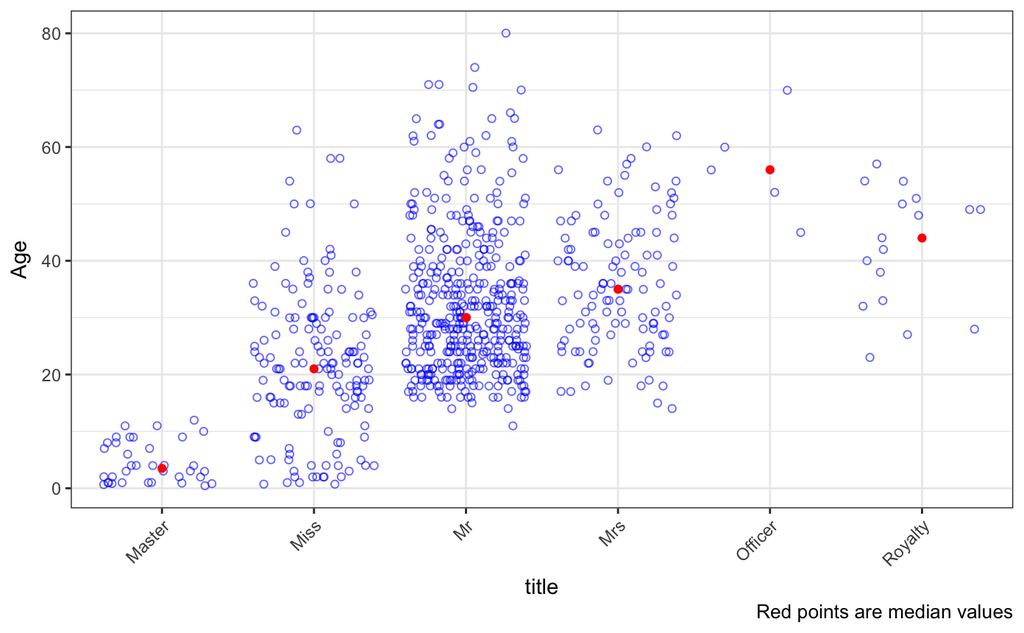

```r
ggplot(train.imp,aes(x=title,y=Age))+
    geom_jitter(shape=21,alpha=.6,col='blue')+
    stat_summary(aes(y = Age,group=1), fun.y=median, colour="red", geom="point",group=1)+
    theme_bw()+
    theme(axis.text.x = element_text(angle = 45, hjust = 1),legend.position="none")+
    labs(caption='Red points are median values')
```

```r
age.predictors <- train.imp %>%
    dplyr::select(-Survived,-Cabin,-Ticket,-Name) %>%
    filter(complete.cases(.))
set.seed(1234)
ctrl <- trainControl(method = "boot",
                     repeats = 5,
                     number = 200
                     )
rpartGrid <- data.frame(maxdepth = seq(4,20,2))
rpartFit <- train(Age~.,
                  data=age.predictors,
                  method='rpart2',
                  trControl = ctrl,
                  tuneGrid = rpartGrid
                  )
rpartFit
```

```
CART

712 samples
  7 predictor

No pre-processing
Resampling: Bootstrapped (200 reps)
Summary of sample sizes: 712, 712, 712, 712, 712, 712, ...
Resampling results across tuning parameters:

  maxdepth  RMSE      Rsquared
   4        12.91352  0.2172555
   6        12.56362  0.2600303
   8        12.37466  0.2835666
  10        12.28184  0.2961068
  12        12.23967  0.3028092
  14        12.23329  0.3046570
  16        12.24043  0.3041673
  18        12.23669  0.3045630
  20        12.23821  0.3044234

RMSE was used to select the optimal model using  the smallest value.
The final value used for the model was maxdepth = 14.
```

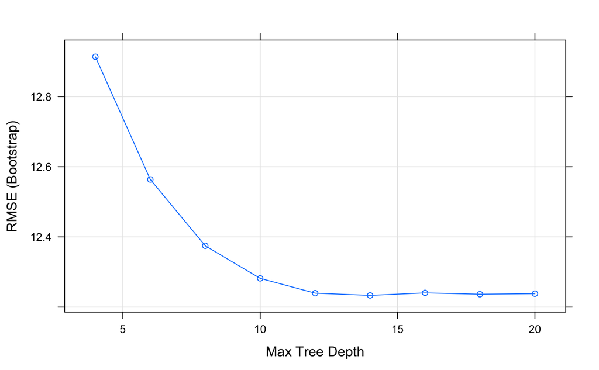

```r
plot(rpartFit)
```

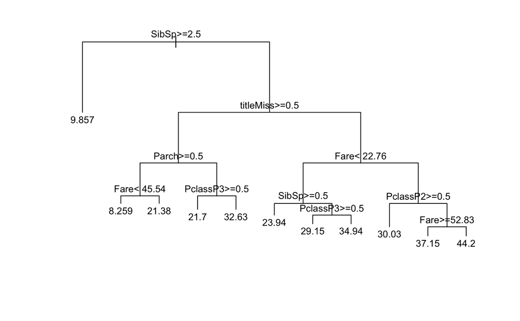

```r
plot(rpartFit$finalModel,margin=0.02)
text(rpartFit$finalModel,cex=0.8)
```

```r
set.seed(1234)
rfGrid <- data.frame(mtry=seq(1,6,1))
ctrl <- trainControl(method = "repeatedcv",
                     repeats = 5
                     )
rfFit <- train(Age~.,
                  data=age.predictors,
                  method='rf',
                  trControl = ctrl,
                  tuneGrid = rfGrid)
rfFit
```

```
Random Forest

712 samples
  7 predictor

No pre-processing
Resampling: Cross-Validated (10 fold, repeated 5 times)
Summary of sample sizes: 642, 640, 642, 641, 640, 639, ...
Resampling results across tuning parameters:

  mtry  RMSE      Rsquared
  1     12.46449  0.3816241
  2     11.33714  0.4192503
  3     11.05166  0.4263448
  4     11.04766  0.4217797
  5     11.10717  0.4152716
  6     11.20324  0.4066238

RMSE was used to select the optimal model using  the smallest value.
The final value used for the model was mtry = 4.
```

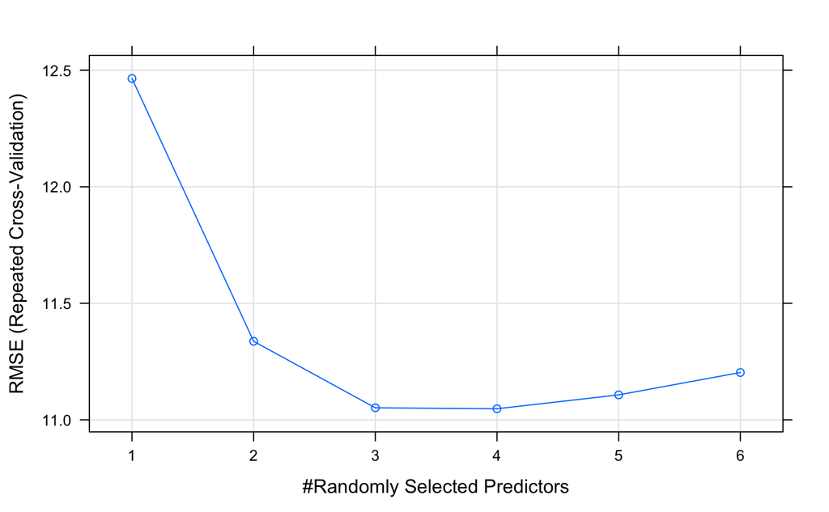

```r
plot(rfFit)
```

I’m going to use the randomForest model. Using the `predict.train()` to predict values of age and plug them back into the imputed data. You can see the blue points which are the imputed values of `Age`. What I noticed is that for all the titles, the imputed Age value seems to be distributed fairly well, except Master. For Master, the three imputed are definitely outliers. I’m going to force these to the median Age.

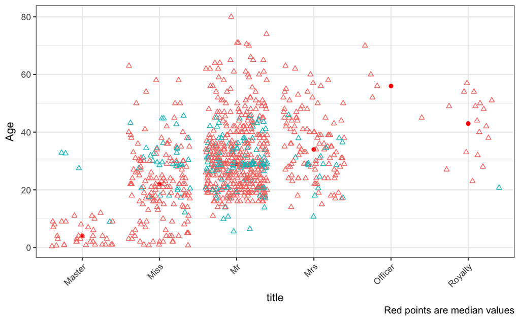

```r
missing.age <- train.imp %>% filter(is.na(Age))
age.predicted <- predict(rfFit, newdata = missing.age)
train.imp %>%
    mutate(AgeMissing = is.na(Age),
           Age = ifelse(AgeMissing,age.predicted,Age)) %>%
    ggplot(aes(x=title,y=Age))+
    stat_summary(aes(y = Age,group=1), fun.y=median, colour="red", geom="point",group=1)+
    geom_jitter(aes(y=Age,col=AgeMissing),shape=2)+
    theme_bw()+
    theme(axis.text.x = element_text(angle = 45, hjust = 1),legend.position="none")+
    labs(caption='Red points are median values')
```

```r
train.imp$Age[is.na(train.imp$Age)] <- age.predicted
train.imp$Age[train.imp$title=='Master' & train.imp$Age > 20] <- median(train.imp$Age[train.imp$title=='Master'],na.rm = T)
```

## Derived Variables

**Child?:** Trying out two engineered variables here - is the passenger a child or not? Using Age=18 as a threshold. And is s/he close enough to be considered a adult by chance? Those between 16 and 18 could be mistaken for not being children. (My way of incorporating a fudge factor in the decision process of ladies & children first.)

```r
train.imp$child <- 0
train.imp$child[train.imp$Age<18] <- 1
train.imp$almostadult <- as.numeric(between(train.imp$Age,16,18))
```

**Really young, or really old?:** Really young ones and older folks would get priority perhaps. Creating two categorical binary variables for these conditions.

```r
train.imp$Young <- ifelse(train.imp$Age<10,1,0)
train.imp$Seniors <- ifelse(train.imp$Age>60,1,0)
```

**Family related:** Let’s also create some variables that talk about family sizes. What’s the total family size – continous variable `TotalFam`. Is the person single, part of a couple or a family? Three categorical variables for these.

```r
train.imp$TotalFam <- train.imp$SibSp + train.imp$Parch + 1
# train.imp$LastName <- train.imp$Name %>% str_extract(pattern = '[a-zA-Z]+(?=,)')
# train.imp$FamSize <- paste0(train.imp$TotalFam,train.imp$LastName)
# train.imp$LastName <- NULL
train.imp$Name <- NULL
train.imp$LargeParCh <- as.numeric(train.imp$Parch>=3)
train.imp$LargeSibSp <- as.numeric(train.imp$SibSp>=3)
train.imp$Single <- ifelse(train.imp$TotalFam==1,1,0)
train.imp$Couple <- ifelse(train.imp$TotalFam==2,1,0)
train.imp$Family <- ifelse(train.imp$TotalFam>2,1,0)
```

**Cabin related:** Extracting the cabin alphabet and number from the cabin variable. Since the cabin numbers could be ordered from left to right or top to bottom on the boat, perhaps only the 1st digit is significant. Also, some folks have more than 1 cabin. Wonder if that’s important. Since lots of unknowns in the `Cabin` variable, all NA values are replaced by ‘U’. Refering to the deck diagram, the topmost decks are A and B, which are closest to the lifeboats. Perhaps that’s important too. Here, I create a bunch of categorical variables based off the original `Cabin`, and then remove it from the dataset.

```r
train.imp$CabinMissing <- as.numeric(is.na(train.raw$Cabin))
train.imp$CabinCode <- map_chr(train.raw$Cabin,~str_split(string = .x,pattern = '')[[1]][1])
train.imp$CabinCode[is.na(train.imp$CabinCode)] <- 'U'
train.imp$CabinNum <- as.numeric(map_chr(train.raw$Cabin,~str_split(string = .x,pattern = '[a-zA-Z]')[[1]][2]))
train.imp$CabinNum <- map_int(train.imp$CabinNum, ~as.integer(str_split(.x,pattern = '',simplify = T)[1][1]))
train.imp$CabinNum[is.na(train.imp$CabinNum)] <- 0
train.imp$TopDeck <- ifelse(train.imp$CabinCode %in% c('A','B'),1,0)
train.imp$MidDeck <- ifelse(train.imp$CabinCode %in% c('C','D'),1,0)
train.imp$LowerDeck <- ifelse(train.imp$TopDeck==0 & train.imp$MidDeck ==0 ,1,0)
train.imp$NumberofCabins <- map_int(train.raw$Cabin,~str_split(string = .x,pattern = ' ')[[1]] %>% length)
train.imp$Cabin <- NULL
```

```r
train.imp$Ticket %>% table() %>% as.numeric() %>% table()
```

```
.
  1   2   3   4   5   6   7
547  94  21  11   2   3   3
```

There seems to be a bit of a pattern here. Tickets starting with 1 are mostly 1st class, those starting with 2 are 2nd class, and 3 - 3rd class. But, I feel it’s a very loose association.

```r
train.imp %>% group_by(Pclass) %>% dplyr::select(Ticket,Pclass) %>% sample_n(5)
```

| Ticket | Pclass |
| --- | --- |
| PC 17485 | P1 |
| PC 17758 | P1 |
| 13567 | P1 |
| 110152 | P1 |
| 17421 | P1 |
| 228414 | P2 |
| S.W./PP 752 | P2 |
| 239855 | P2 |
| 250644 | P2 |
| 11668 | P2 |

[output cut: 5 more lines]

What I’m going to do is clean up the columns (remove special characters, spaces etc), then split the `Ticket` column into four: `TicketChar`, `TicketNum`,`TicketNumLength`, `TicketNumStart`. (Upon running the script a few times, I’ve decided to get rid of `TicketNum`, but I’m commenting the code for future ref). The `TicketChar` variable as this distribution:

```r
train.imp %<>%
    mutate(
        Ticket = str_to_upper(Ticket) %>%
            str_replace_all(pattern = regex(pattern = '[.\\/]'),replacement = ''),
        TicketNum = str_extract(Ticket,pattern = regex('([0-9]){3,}')),
        TicketNumStart = map_int(TicketNum,~as.integer(str_split(.x,pattern = '',simplify = T)[1])),
        TicketNumLen = map_int(TicketNum,~dim(str_split(.x,pattern = '',simplify = T))[2]),
        TicketChar = str_extract(Ticket,pattern = regex('^[a-zA-Z/\\.]+'))
        ) %>%
    mutate(
        TicketChar = ifelse(is.na(TicketChar),'U',TicketChar),
        TicketNumStart = ifelse(is.na(TicketNumStart),0,TicketNumStart),
        TicketNumLen = ifelse(is.na(TicketNumLen),0,TicketNumLen),
    )
train.imp$Ticket <- NULL
train.imp$TicketNum <- NULL
table(train.imp$TicketChar)
```

```
      A      AS       C      CA CASOTON      FA      FC     FCC    LINE      PC      PP
     28       1       5      41       1       1       1       5       4      60       3
    PPP      SC     SCA    SCAH    SCOW SCPARIS     SOC     SOP    SOPP  SOTONO SOTONOQ
      2       1       1       3       1      11       6       1       3       2      15
     SP   STONO    SWPP       U      WC     WEP
      1      18       2     661      10       3
```

```r
table(train.imp$TicketNumLen)
```

```
  1   3   4   5   6   7
  6   7 165 246 423  44
```

```r
table(train.imp$TicketNumStart)
```

```
  0   1   2   3   4   5   6   7   8   9
  6 231 230 365  15   9  14  15   3   3
```

## Winzoring Variables

The `fare` variable has one massive outlier. Winzorising this variable using the 95th percentile value as the cutoff.

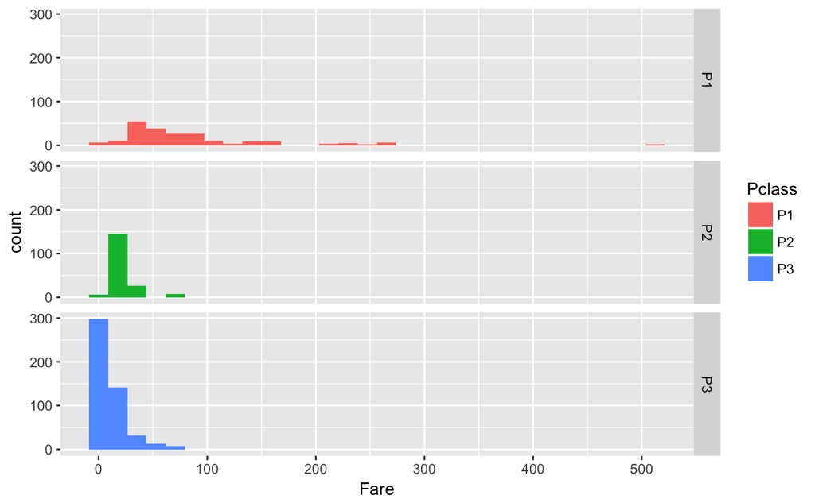

```r
ggplot(train.imp,aes(x=Fare,fill=Pclass))+geom_histogram()+facet_grid(Pclass~.)
```

```r
quantile(train.imp$Fare[train.imp$Pclass=='P1'],probs = c(.1,.25,.5,.75,.95))
```

```
      10%       25%       50%       75%       95%
 26.55000  30.92395  60.28750  93.50000 232.52395
```

```r
train.imp$Fare[train.imp$Fare>232] <- 232
```

# Modeling

## Extreme Gradient Boosting (xgboost)

```r
ctrl <- trainControl(method = "repeatedcv",
                     repeats = 1,
                     verboseIter = F,
                     classProbs = TRUE,
                     summaryFunction = twoClassSummary,
                     sampling = 'smote'
                     )

xgbGrid <- expand.grid(
    nrounds=c(3,4,5),
    max_depth=c(4,5,6),
    eta=c(0.35,0.4,0.45),
    gamma=c(0.8),
    colsample_bytree=1,
    min_child_weight=1,
    subsample=1
)
dumV <- dummyVars(formula = Survived~.,data = train.imp)
Dtrain <- predict(dumV,train.imp)
xgbFit <- train(
    x=Dtrain,
    y=train.imp$Survived,
    method = 'xgbTree',
    trControl = ctrl,
    # metric = "Kappa",
    tuneGrid = xgbGrid,
    verbose = TRUE
)
xgbFit
plot(xgbFit)
xgb.importance(feature_names = colnames(Dtrain),model = xgbFit$finalModel)
xgb.importance(feature_names = colnames(Dtrain),model = xgbFit$finalModel) %>%
xgb.ggplot.importance()

densityplot(xgbFit,pch='|')
predict(xgbFit,type = 'raw') -> train.Class
predict(xgbFit,type = 'prob') -> train.Probs
histogram(~Survived+Dead,train.Probs)
```

[output not shown]

```r
# response <- 'Survived'
# predictors <- names(train.imp)[names(train.imp)!=response]
ctrl <- trainControl(method = "repeatedcv",
                     repeats = 1,
                     verboseIter = T,
                     classProbs = TRUE,
                     summaryFunction = twoClassSummary,
                     sampling = 'smote'
                     )

rfGrid <- data.frame(mtry=seq(8,12))

rfFit.y <- train(
    form = Survived~.,
    data = train.imp,
    method = 'rf',
    trControl = ctrl,
    # metric = "Kappa",
    tuneGrid = rfGrid,
    verbose = TRUE
)
rfFit.y
plot(rfFit.y)


densityplot(rfFit.y,pch='|')
predict(rfFit.y,type = 'raw') -> train.rf.Class
predict(rfFit.y,type = 'prob') -> train.rf.Probs
histogram(~Survived+Dead,train.rf.Probs)
```

[output not shown]

```r
ctrl <- trainControl(method = "repeatedcv",
                     repeats = 1,
                     verboseIter = T,
                     classProbs = TRUE,
                     summaryFunction = twoClassSummary,
                     # sampling = 'smote'
                     )
gbmGrid <- expand.grid(
   n.trees=c(500,700,900,1100),
   interaction.depth=c(1,2,3),
   shrinkage=c(0.1,0.01),
   n.minobsinnode=10
)

dumV <- dummyVars(formula = Survived~.,data = train.imp)
Dtrain <- predict(dumV,train.imp)

boostFit <- train(
    x = Dtrain,
    y = boost.train$Survived,
    trControl=ctrl,
    method='gbm',
    tuneGrid=gbmGrid
)
boostFit
plot(boostFit)
xyplot(oobag.improve~1:1100,data=boostFit$finalModel,alpha=.5,xlab = 'n.trees')
plot(varImp(boostFit))
```

[output not shown]

## Compare models

```r
re <- resamples(x = list(xgb=xgbFit,rf=rfFit.y))
summary(re)
```

[output not shown]